# 5_Data visualisation

```r
write_csv (interviews_plotting, file = "data_output/interviews_plotting.csv")
```

```
Error: Cannot open file for writing:
* 'data_output/interviews_plotting.csv'
```

vamos a usar el paquete ggplot2 que está en tidyverse:

```r
interviews_plotting <- read_csv("data_output/interviews_plotting.csv")
```

ggplot2 aporta una interfaz para especificar las variables, la forma de presentarlas y las propiedades visuales este trabajo en capas permite que sea fácil mutar de un tipo de gráfico a otro trabaja mejor con datos en formato long (una columna por cada dimensión y una fila por cada observación)

cada gráfico debe aportar: * datos * mapeo de la estética (descripción de cómo las variables se mapean a los atributos gráficos y los atributos visuales de los datos, como el eje y y el x, el color, el relleno, la forma y la transparencia) * objetos geométricos (geoms), básicamente tipo de gráfico

entonces, la plantilla para el código sería esta:

DATA %>% ggplot(aes(MAPPINGS)) + GEOM_FUNCTION()

ejemplo:

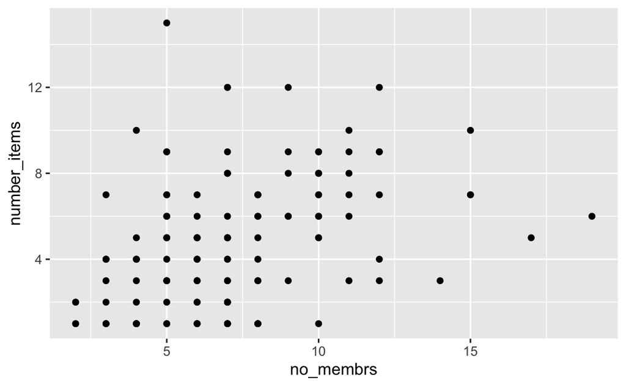

algunas cuestiones importantes: * todo lo que vaya dentro de la funcion ggplot() puede ser accedido por cualqquier capa de geom * podés dar mappings específicos para cada geom * el signo + hay que ponerlo siempre al final de la linea

# Construir gráficos de forma interactiva

si miramos el gráfico anterior vemos que hay menos puntos que filas de observciones y que todos los puntos parecen estar en la intersección de las variables. parecería ser que hay observaciones superpuestas se puede resolver: 1) cambiando transparencia, 2) agregando movimiento/temblor a los puntos (jittering)

opción 1: argumento alpha, que va de 0 a 1.

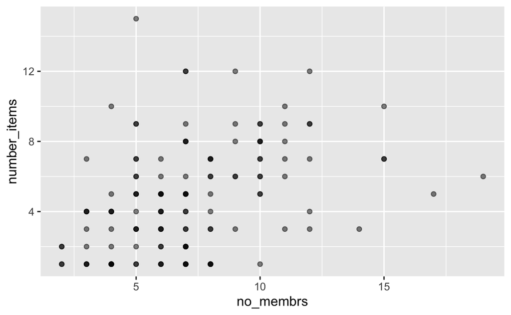

opción 2:

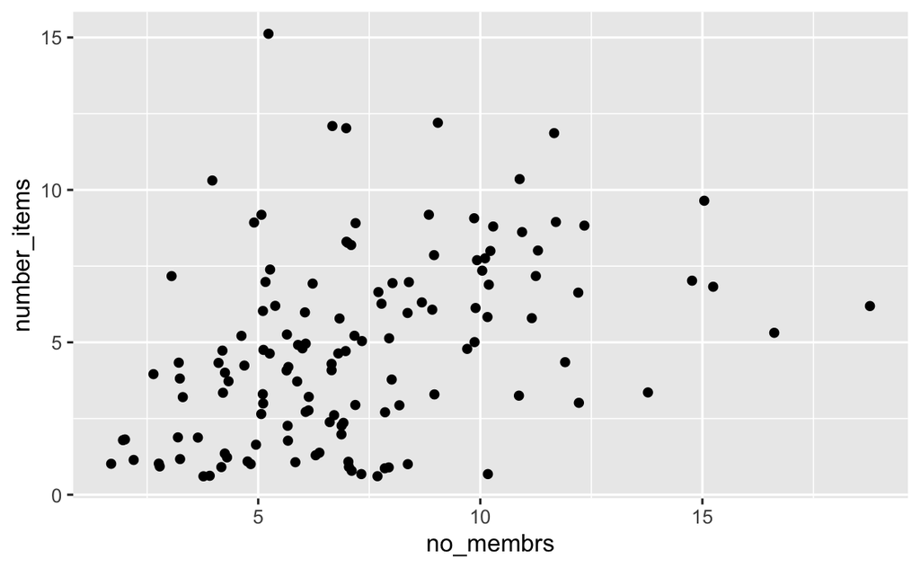

si quiero asignar distintos colores:

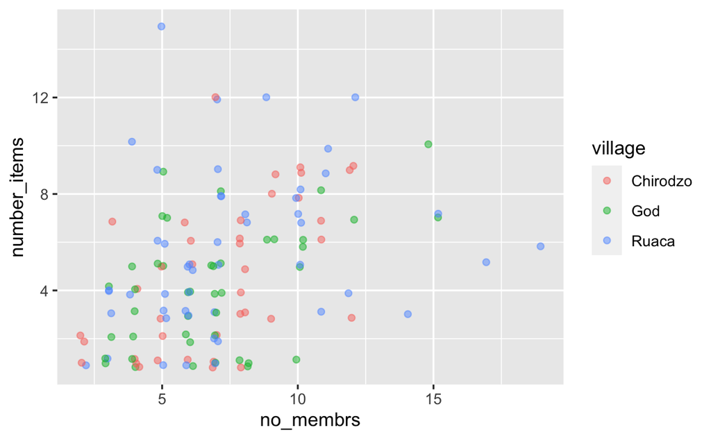